# Codebook

**Authors:** Lauren Baker  
Documenting existing data files of DaanMatch with information about location, owner, "version", source etc.

```python
import boto3
import numpy as np
import pandas as pd
pd.plotting.register_matplotlib_converters()
import matplotlib.pyplot as plt
%matplotlib inline
from collections import Counter
import statistics
```

```python
client = boto3.client('s3')
resource = boto3.resource('s3')
my_bucket = resource.Bucket('daanmatchdatafiles')
```

# Dadra_Nagar_Haveli_2016.xlsx

## TOC:

- About this dataset
- What's in this dataset
- Codebook
  - Missing values
  - Summary statistics
- Columns
  - CIN
  - COMPANY_NAME
  - COMPANY_CLASS
  - COMPANY_CATEGORY
  - COMPANY_SUBCAT
  - COMPANY_STATUS
  - DATE_OF_REGISTRATION
  - REGISTERED_STATE
  - Authorized Capital (Rs.)
  - PAIDUP_CAPITAL (Rs.)
  - PRINCIPAL_BUSINESS_ACTIVITY_CODE
  - REGISTERED_OFFICE_ADDRESS
  - EMAIL_ID
  - LATEST ANNUAL REPORT FILING FY END DATE
  - LATEST BALANCE SHEET FILING FY END DATE

**About this dataset**  
Data provided by: Unknown.  
Source: https://daanmatchdatafiles.s3.us-west-1.amazonaws.com/DaanMatch_DataFiles/Dadar_Nagar_Haveli_2016.xlsx  
Type: xlsx  
Last Modified: May 29, 2021, 22:52:46 (UTC-04:00)  
Size: 79.5 KB

```python
path = "s3://daanmatchdatafiles/DaanMatch_DataFiles/Dadar_Nagar_Haveli_2016.xlsx"
Dadra_Nagar_Haveli_2016 = pd.ExcelFile(path)
print(Dadra_Nagar_Haveli_2016.sheet_names)
```

```
['Sheet3']
```

```python
Dadra_Nagar_Haveli_2016 = Dadra_Nagar_Haveli_2016.parse('Sheet3')
Dadra_Nagar_Haveli_2016.head()
```

|  | CIN | COMPANY_NAME | COMPANY_CLASS | COMPANY_CATEGORY | COMPANY_SUBCAT | COMPANY_STATUS | DATE_OF_REGISTRATION | REGISTERED_STATE | Authorized Capital (Rs.) | PAIDUP_CAPITAL (RS.) | PRINCIPAL_BUSINESS_ACTIVITY_CODE | REGISTERED_OFFICE_ADDRESS | EMAIL_ID | LATEST ANNUAL REPORT FILING FY END DATE | LATEST BALANCE SHEET FILING FY END DATE |
| --- | --- | --- | --- | --- | --- | --- | --- | --- | --- | --- | --- | --- | --- | --- | --- |
| 0 | U51109DN2010PTC005504 | KAPOOR MERCANTILE PRIVATE LIMITED | Private | Company limited by Shares | Non-govt company | ACTIVE | 2010-02-17 | Dadra and Nagar Haveli | 30000000 | 540000 | 51109 | PLOT NO 17, SURVEY NO 121/P,SILVASSA INDUSTRIA... | rawal_bhv@yahoo.co.in | 2015-03-31 | 2015-03-31 |
| 1 | U17291DN2013PTC005501 | AKSHAT FREIGHT CARRIERS PRIVATE LIMITED | Private | Company limited by Shares | Non-govt company | ACTIVE | 2013-02-20 | Dadra and Nagar Haveli | 100000000 | 48000000 | 17291 | PLOT NO 65/B, PIPARIA INDUSTRIAL ESTATE,PIPARI... | rawal_bhv@yahoo.co.in | 2015-03-31 | 2015-03-31 |
| 2 | U99999DN1995PLC000093 | AEC SSANGYONG LTD | Public | Company limited by Shares | Non-govt company | INACTIVE UNDER SECTION 455 OF CA,2013 | 1995-08-01 | Dadra and Nagar Haveli | 500000 | 0 | 99999 | SURVEY NO.210&ONS,VILLAGE MORKHAL,PO.SILVASSA ... |  | 0 | 0 |
| 3 | U99999DN1991PLC000037 | SILVASSA STANDARD TWIST AND TILES PVT.LTD. | Private | Company limited by Shares | Non-govt company | INACTIVE UNDER SECTION 455 OF CA,2013 | 1991-02-11 | Dadra and Nagar Haveli | 500000 | 0 | 99999 | 40-INDUS. ESTATE, PIPARIASILVASSADADAR N. HAVA... |  | 0 | 0 |
| 4 | U99999DN1990PLC000033 | SILWINES PVT. LTD. | Private | Company limited by Shares | Non-govt company | INACTIVE UNDER SECTION 455 OF CA,2013 | 1990-04-06 | Dadra and Nagar Haveli | 100000 | 0 | 99999 | C/O. SILPHAR LABORATORIES P.B.NO. 33SILVASSA (... |  | 0 | 0 |

**What's in this dataset?**

```python
print("Shape:", Dadra_Nagar_Haveli_2016.shape)
print("Rows:", Dadra_Nagar_Haveli_2016.shape[0])
print("Columns:", Dadra_Nagar_Haveli_2016.shape[1])
print("Each row is a company.")
```

```
Shape: (472, 15)
Rows: 472
Columns: 15
Each row is a company.
```

**Codebook**

```python
Dadra_Nagar_Haveli_2016_columns = [column for column in Dadra_Nagar_Haveli_2016.columns]
Dadra_Nagar_Haveli_2016_description = ["Corporate Identification Number in India (CIN) is a 21 digit alpha-numeric code issued to companies incorporated within India on being registered with Registrar of Companies (RCA).",
                                           "Name of Company.",
                                           "Class of Company: Private or Public.",
                                           "Category of Company: Limited by Shares, Limited by Guarantee, Unlimited Company.",
                                           "Subcategory of Company: Non-govt, Union Gtvt, State Govt, Subsidiary of Foreign Company, Guarantee and Association Company.",
                                           "Status of Company.",
                                           "Timestamp of date of registration: YYYY-MM-DD HH:MM:SS.",
                                           "State of registration.",
                                           "Authorized capital in rupees (Rs.).",
                                           "Paid up capital in rupees (Rs.).",
                                           "Principal Business code that classifies the main type of product/service sold.",
                                           "Address of registered office.",
                                           "Company email.",
                                           "Latest annual report filing fiscal year end date: YYYY-MM-DD.",
                                           "Latest balance sheet filing fiscal year end date: YYYY-MM-DD."]
Dadra_Nagar_Haveli_2016_dtypes = [dtype for dtype in Dadra_Nagar_Haveli_2016.dtypes]

data = {"Column Name": Dadra_Nagar_Haveli_2016_columns, "Description": Dadra_Nagar_Haveli_2016_description, "Type": Dadra_Nagar_Haveli_2016_dtypes}
Dadra_Nagar_Haveli_2016_codebook = pd.DataFrame(data)
Dadra_Nagar_Haveli_2016_codebook.style.set_properties(subset=['Description'], **{'width': '600px'})
```

|  | Column Name | Description | Type |
| --- | --- | --- | --- |
| 0 | CIN | Corporate Identification Number in India (CIN) is a 21 digit alpha-numeric code issued to companies incorporated within India on being registered with Registrar of Companies (RCA). | object |
| 1 | COMPANY_NAME | Name of Company. | object |
| 2 | COMPANY_CLASS | Class of Company: Private or Public. | object |
| 3 | COMPANY_CATEGORY | Category of Company: Limited by Shares, Limited by Guarantee, Unlimited Company. | object |
| 4 | COMPANY_SUBCAT | Subcategory of Company: Non-govt, Union Gtvt, State Govt, Subsidiary of Foreign Company, Guarantee and Association Company. | object |
| 5 | COMPANY_STATUS | Status of Company. | object |
| 6 | DATE_OF_REGISTRATION | Timestamp of date of registration: YYYY-MM-DD HH:MM:SS. | object |
| 7 | REGISTERED_STATE | State of registration. | object |
| 8 | Authorized Capital (Rs.) | Authorized capital in rupees (Rs.). | int64 |
| 9 | PAIDUP_CAPITAL (RS.) | Paid up capital in rupees (Rs.). | int64 |
| 10 | PRINCIPAL_BUSINESS_ACTIVITY_CODE | Principal Business code that classifies the main type of product/service sold. | int64 |
| 11 | REGISTERED_OFFICE_ADDRESS | Address of registered office. | object |
| 12 | EMAIL_ID | Company email. | object |
| 13 | LATEST ANNUAL REPORT FILING FY END DATE | Latest annual report filing fiscal year end date: YYYY-MM-DD. | object |
| 14 | LATEST BALANCE SHEET FILING FY END DATE | Latest balance sheet filing fiscal year end date: YYYY-MM-DD. | object |

**Missing values**

```python
Dadra_Nagar_Haveli_2016.isnull().sum()
```

```
CIN                                        0
COMPANY_NAME                               0
COMPANY_CLASS                              0
COMPANY_CATEGORY                           0
COMPANY_SUBCAT                             0
COMPANY_STATUS                             0
DATE_OF_REGISTRATION                       0
REGISTERED_STATE                           0
Authorized Capital  (Rs.)                  0
 PAIDUP_CAPITAL (RS.)                      0
PRINCIPAL_BUSINESS_ACTIVITY_CODE           0
REGISTERED_OFFICE_ADDRESS                  0
EMAIL_ID                                   0
LATEST ANNUAL REPORT FILING FY END DATE    0
LATEST BALANCE SHEET FILING FY END DATE    0
dtype: int64
```

**Summary statistics**

```python
Dadra_Nagar_Haveli_2016.describe()
```

|  | Authorized Capital (Rs.) | PAIDUP_CAPITAL (RS.) | PRINCIPAL_BUSINESS_ACTIVITY_CODE |
| --- | --- | --- | --- |
| count | 4.720000e+02 | 4.720000e+02 | 472.000000 |
| mean | 2.582305e+08 | 1.260492e+08 | 43200.557203 |
| std | 2.294642e+09 | 1.118912e+09 | 24076.121321 |
| min | 0.000000e+00 | 0.000000e+00 | 1111.000000 |
| 25% | 1.000000e+05 | 1.000000e+05 | 24230.750000 |
| 50% | 6.500000e+05 | 1.000000e+05 | 45200.000000 |
| 75% | 1.212500e+07 | 6.295700e+06 | 56458.000000 |
| max | 4.000000e+10 | 1.698084e+10 | 99999.000000 |

## Columns

### CIN

Corporate Identification Number in India (CIN) is a 21 digit alpha-numeric code issued to companies incorporated within India on being registered with Registrar of Companies (RCA).

```python
column = Dadra_Nagar_Haveli_2016["CIN"]
column
```

```
0      U51109DN2010PTC005504
1      U17291DN2013PTC005501
2      U99999DN1995PLC000093
3      U99999DN1991PLC000037
4      U99999DN1990PLC000033
               ...
467    U27209DN2003PTC000173
468    U27203DN2012PTC000388
469    U27203DN2008PTC000267
470    U17299DN2016PTC005498
471    U65191DH1888PLC000008
Name: CIN, Length: 472, dtype: object
```

```python
# Check if all rows have 21 digits
CIN_length = [len(CIN) for CIN in column]
print("Rows without 21 digits:", sum([length != 21 for length in CIN_length]))

print("No. of unique values:", len(column.unique()))

# Check for duplicates
counter = dict(Counter(column))
duplicates = { key:value for key, value in counter.items() if value > 1}
print("Duplicates:", duplicates)
```

```
Rows without 21 digits: 0
No. of unique values: 472
Duplicates: {}
```

### COMPANY_NAME

Name of Company.  
There is trailing and leading whitespace. Need to strip strings.

```python
column = Dadra_Nagar_Haveli_2016["COMPANY_NAME"]
column
```

```
0                KAPOOR MERCANTILE PRIVATE LIMITED
1          AKSHAT FREIGHT CARRIERS PRIVATE LIMITED
2                                AEC SSANGYONG LTD
3        SILVASSA STANDARD TWIST AND TILES PVT.LTD.
4                               SILWINES PVT. LTD.
                            ...
467    DHARMANANDAN STEEL AND METAL PRIVATE LIMITED
468                  JAIN ALUFOILS PRIVATE LIMITED
469             GLACIER ALLUMINIUM PRIVATE LIMITED
470              UNOVEL INDUSTRIES PRIVATE LIMITED
471                            XYZ Company pvt Ltd
Name: COMPANY_NAME, Length: 472, dtype: object
```

```python
# Strip strings
stripped_name = column.str.strip()
print("Invalid names:", sum(stripped_name.isnull()))

print("No. of unique values:", len(column.unique()))

# Check for duplicates
counter = dict(Counter(column))
duplicates = { key:value for key, value in counter.items() if value > 1}
print("Duplicates:", duplicates)
if len(duplicates) > 0:
    print("No. of duplicates:", len(duplicates))
```

```
Invalid names: 0
No. of unique values: 471
Duplicates: {'SAI AGRO PESTICIDES COMPANY PVT.LTD.   ': 2}
No. of duplicates: 1
```

```python
Dadra_Nagar_Haveli_2016[Dadra_Nagar_Haveli_2016["COMPANY_NAME"].isin(duplicates)]
```

|  | CIN | COMPANY_NAME | COMPANY_CLASS | COMPANY_CATEGORY | COMPANY_SUBCAT | COMPANY_STATUS | DATE_OF_REGISTRATION | REGISTERED_STATE | Authorized Capital (Rs.) | PAIDUP_CAPITAL (RS.) | PRINCIPAL_BUSINESS_ACTIVITY_CODE | REGISTERED_OFFICE_ADDRESS | EMAIL_ID | LATEST ANNUAL REPORT FILING FY END DATE | LATEST BALANCE SHEET FILING FY END DATE |
| --- | --- | --- | --- | --- | --- | --- | --- | --- | --- | --- | --- | --- | --- | --- | --- |
| 201 | U25199DN1974PTC006789 | SAI AGRO PESTICIDES COMPANY PVT.LTD. | Private | Company limited by Shares | Non-govt company | INACTIVE UNDER SECTION 455 OF CA,2013 | 1974-04-30 | Dadra and Nagar Haveli | 200000 | 0 | 25199 | SILVASSA,VIA-VAPI,DADRA-NAGAR HAVELI. SILVAS... |  | 0 | 0 |
| 413 | U99999DN1974PTC000002 | SAI AGRO PESTICIDES COMPANY PVT.LTD. | Private | Company limited by Shares | Non-govt company | INACTIVE UNDER SECTION 455 OF CA,2013 | 1974-04-30 | Dadra and Nagar Haveli | 200000 | 1000 | 99999 | SILVASSA, VIA VAPI,DADRA NAGAR HAVELI.SILVASSA... |  | 0 | 0 |

Duplicates in `COMPANY_NAME` does not mean the rows are duplicates.

### COMPANY_CLASS

Class of Company: Private or Public.

```python
column = Dadra_Nagar_Haveli_2016["COMPANY_CLASS"]
column
```

```
0      Private
1      Private
2       Public
3      Private
4      Private
        ...
467    Private
468    Private
469    Private
470    Private
471
Name: COMPANY_CLASS, Length: 472, dtype: object
```

```python
print("Unique values:", column.unique())
print("No. of unique values:", len(column.unique()))

# Number of empty strings
print("Empty strings:", sum(column == " "))

# Table of number of each class
table = column.value_counts().rename_axis('Class').reset_index(name='Count')
table
```

```
Unique values: ['Private' 'Public' ' ']
No. of unique values: 3
Empty strings: 1
```

|  | Class | Count |
| --- | --- | --- |
| 0 | Private | 388 |
| 1 | Public | 83 |
| 2 |  | 1 |

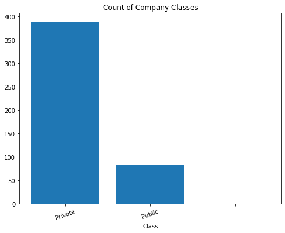

```python
# Plot number of each class
plt.figure(figsize = (8, 6))
plt.bar(table["Class"], table["Count"])
plt.title("Count of Company Classes")
plt.xlabel("Class")
plt.xticks(rotation = 20);
```

### COMPANY_CATEGORY

Category of Company: Limited by Shares, Limited by Guarantee, Unlimited Company.

```python
column = Dadra_Nagar_Haveli_2016["COMPANY_CATEGORY"]
column
```

```
0         Company limited by Shares
1         Company limited by Shares
2         Company limited by Shares
3         Company limited by Shares
4         Company limited by Shares
                   ...
467       Company limited by Shares
468       Company limited by Shares
469       Company limited by Shares
470       Company limited by Shares
471    Company Limited by Guarantee
Name: COMPANY_CATEGORY, Length: 472, dtype: object
```

```python
print("Unique values:", column.unique())
print("No. of unique values:", len(column.unique()))

# Number of empty strings
print("Empty strings:", sum(column == " "))

# Table of number of each category
table = column.value_counts().rename_axis('Category').reset_index(name='Count')
table
```

```
Unique values: ['Company limited by Shares' 'Company Limited by Guarantee']
No. of unique values: 2
Empty strings: 0
```

|  | Category | Count |
| --- | --- | --- |
| 0 | Company limited by Shares | 471 |
| 1 | Company Limited by Guarantee | 1 |

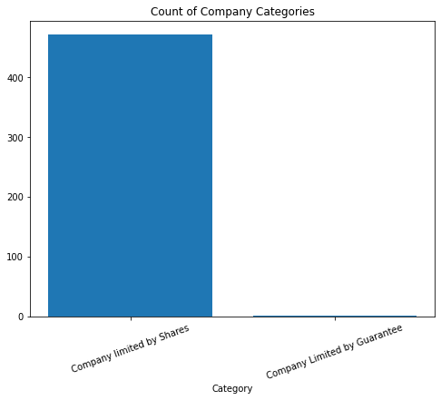

```python
# Plot number of each Category
plt.figure(figsize = (8, 6))
plt.bar(table["Category"], table["Count"])
plt.title("Count of Company Categories")
plt.xlabel("Category")
plt.xticks(rotation = 20);
```

### COMPANY_SUBCAT

Subcategory of Company: Non-govt, Union Gtvt, State Govt, Subsidiary of Foreign Company, Guarantee and Association Company.

```python
column = Dadra_Nagar_Haveli_2016["COMPANY_SUBCAT"]
column
```

```
0      Non-govt company
1      Non-govt company
2      Non-govt company
3      Non-govt company
4      Non-govt company
             ...
467    Non-govt company
468    Non-govt company
469    Non-govt company
470    Non-govt company
471
Name: COMPANY_SUBCAT, Length: 472, dtype: object
```

```python
print("Unique values:", column.unique())
print("No. of unique values:", len(column.unique()))

# Number of empty strings
print("Empty strings:", sum(column == " "))

# Table of number of each sub-category
table = column.value_counts().rename_axis('Sub-category').reset_index(name='Count')
table
```

```
Unique values: ['Non-govt company' 'Union Govt company' 'Subsidiary of Foreign Company'
 ' ']
No. of unique values: 4
Empty strings: 1
```

|  | Sub-category | Count |
| --- | --- | --- |
| 0 | Non-govt company | 466 |
| 1 | Union Govt company | 3 |
| 2 | Subsidiary of Foreign Company | 2 |
| 3 |  | 1 |

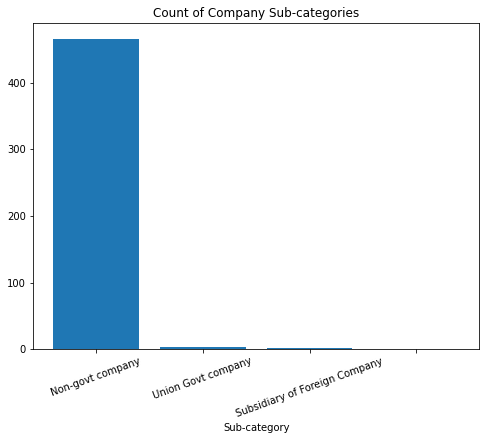

```python
# Plot number of each sub-category
plt.figure(figsize = (8, 6))
plt.bar(table["Sub-category"], table["Count"])
plt.title("Count of Company Sub-categories")
plt.xlabel("Sub-category")
plt.xticks(rotation = 20);
```

### COMPANY_STATUS

Status of Company.

```python
column = Dadra_Nagar_Haveli_2016["COMPANY_STATUS"]
column
```

```
0                                     ACTIVE
1                                     ACTIVE
2      INACTIVE UNDER SECTION 455 OF CA,2013
3      INACTIVE UNDER SECTION 455 OF CA,2013
4      INACTIVE UNDER SECTION 455 OF CA,2013
                       ...
467                               STRUCK-OFF
468                                   ACTIVE
469                                   ACTIVE
470                                   ACTIVE
471                                   ACTIVE
Name: COMPANY_STATUS, Length: 472, dtype: object
```

```python
print("Unique values:", column.unique())
print("No. of unique values:", len(column.unique()))

# Number of empty strings
print("Empty strings:", sum(column == " "))

# Table of number of each status
counter = dict(Counter(column))
count = { key:[value] for key, value in counter.items()}
table = pd.DataFrame.from_dict(count).rename(columns={" ": "Empty"})
table = table.melt(var_name="Status", value_name="Count")
table
```

```
Unique values: ['ACTIVE' 'INACTIVE UNDER SECTION 455 OF CA,2013'
 'UNDER PROCESS OF STRUCK-OFF' 'STRUCK-OFF' 'AMALGAMATED'
 'CONVERTED TO LLP AND DISSOLVED' 'CONVERTED TO LLP']
No. of unique values: 7
Empty strings: 0
```

|  | Status | Count |
| --- | --- | --- |
| 0 | ACTIVE | 365 |
| 1 | INACTIVE UNDER SECTION 455 OF CA,2013 | 48 |
| 2 | UNDER PROCESS OF STRUCK-OFF | 9 |
| 3 | STRUCK-OFF | 41 |
| 4 | AMALGAMATED | 6 |
| 5 | CONVERTED TO LLP AND DISSOLVED | 1 |
| 6 | CONVERTED TO LLP | 2 |

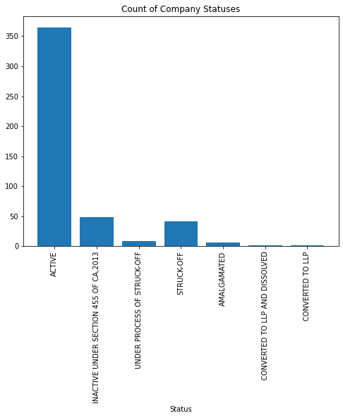

```python
# Plot number of each status
plt.figure(figsize = (8, 6))
plt.bar(table["Status"], table["Count"])
plt.title("Count of Company Statuses")
plt.xlabel("Status")
plt.xticks(rotation = 90);
```

### DATE_OF_REGISTRATION

Timestamp of date of registration:  
Inconsistant format with string and timestamp objects.

```python
column = Dadra_Nagar_Haveli_2016["DATE_OF_REGISTRATION"]
column
```

```
0               2010-02-17
1               2013-02-20
2               1995-08-01
3               1991-02-11
4               1990-04-06
              ...
467             2003-12-29
468             2012-01-06
469             2008-01-23
470             2016-07-28
471    2009-01-12 00:00:00
Name: DATE_OF_REGISTRATION, Length: 472, dtype: object
```

```python
# Number of null values
print("Null:", sum(column.isnull()))

# Drop null values
cleaned = column.dropna()
# Convert all objects to str in YYYY-MM-DD format
dates = cleaned.astype(str).apply(lambda x: x[:10])

# Range
print("Min:", min(dates))
print("Max:", max(dates))
```

```
Null: 0
Min: 1960-11-26
Max: 2016-11-03
```

```python
years = dates.apply(lambda x: int(x[:4]))
# Table of number of each year
counter = dict(Counter(years))
count = { key:[value] for key, value in counter.items()}
table = pd.DataFrame.from_dict(count)
table = table.melt(var_name="Date", value_name="Count")
print("No. of unique values:", table.shape[0])
table
```

```
No. of unique values: 42
```

|  | Date | Count |
| --- | --- | --- |
| 0 | 2010 | 39 |
| 1 | 2013 | 23 |
| 2 | 1995 | 23 |
| 3 | 1991 | 6 |
| 4 | 1990 | 3 |
| 5 | 1987 | 11 |
| 6 | 1997 | 12 |
| 7 | 1989 | 5 |
| 8 | 1999 | 13 |
| 9 | 2008 | 24 |
| 10 | 2015 | 16 |
| 11 | 2001 | 4 |
| 12 | 2011 | 24 |
| 13 | 1996 | 15 |
| 14 | 2007 | 45 |
| 15 | 2004 | 8 |
| 16 | 2014 | 16 |
| 17 | 1979 | 5 |
| 18 | 2006 | 35 |
| 19 | 2012 | 24 |
| 20 | 2009 | 16 |
| 21 | 2005 | 6 |
| 22 | 1998 | 4 |
| 23 | 2000 | 10 |
| 24 | 1992 | 6 |
| 25 | 1988 | 7 |
| 26 | 2016 | 13 |
| 27 | 1994 | 16 |
| 28 | 1993 | 12 |
| 29 | 1982 | 4 |
| 30 | 2003 | 7 |
| 31 | 1986 | 2 |
| 32 | 1983 | 2 |
| 33 | 1974 | 2 |
| 34 | 1985 | 2 |
| 35 | 1960 | 1 |
| 36 | 2002 | 5 |
| 37 | 1961 | 1 |
| 38 | 1978 | 1 |
| 39 | 1972 | 2 |
| 40 | 1984 | 1 |
| 41 | 1975 | 1 |

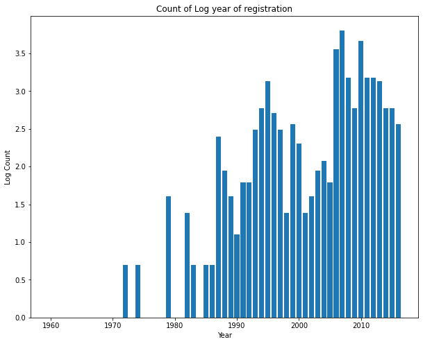

```python
# Plot of number of each year
plt.figure(figsize = (10, 8))
plt.bar(table["Date"], np.log(table["Count"]))
plt.title("Count of Log year of registration")
plt.ylabel("Log Count")
plt.xlabel("Year");
```

### REGISTERED_STATE

State of registration.

```python
column = Dadra_Nagar_Haveli_2016["REGISTERED_STATE"]
column
```

```
0      Dadra and Nagar Haveli
1      Dadra and Nagar Haveli
2      Dadra and Nagar Haveli
3      Dadra and Nagar Haveli
4      Dadra and Nagar Haveli
                ...
467    Dadra and Nagar Haveli
468    Dadra and Nagar Haveli
469    Dadra and Nagar Haveli
470    Dadra and Nagar Haveli
471             Dadar & Nagar
Name: REGISTERED_STATE, Length: 472, dtype: object
```

```python
print("Unique values:", column.unique())
print("No. of unique values:", len(column.unique()))

# Number of empty strings
print("Empty strings:", sum(column == " "))

# Table of number of each state
counter = dict(Counter(column))
count = { key:[value] for key, value in counter.items()}
table = pd.DataFrame.from_dict(count).rename(columns={" ": "Empty"})
table = table.melt(var_name="State", value_name="Count")
table
```

```
Unique values: ['Dadra and Nagar Haveli' 'Dadar & Nagar']
No. of unique values: 2
Empty strings: 0
```

|  | State | Count |
| --- | --- | --- |
| 0 | Dadra and Nagar Haveli | 471 |
| 1 | Dadar & Nagar | 1 |

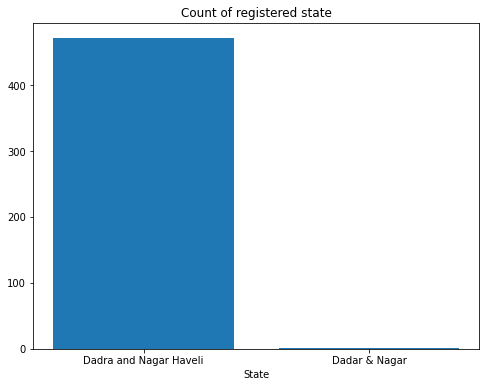

```python
# Plot of number of each state
plt.figure(figsize = (8, 6))
plt.bar(table["State"], table["Count"])
plt.title("Count of registered state")
plt.xlabel("State");
```

### Authorized Capital (Rs.)

Authorized capital in rupees (Rs.). Note that there are two white spaces between Capital and (Rs.) in column title.

```python
column = Dadra_Nagar_Haveli_2016["Authorized Capital  (Rs.)"]
column
```

```
0       30000000
1      100000000
2         500000
3         500000
4         100000
         ...
467       200000
468     10000000
469     65000000
470       100000
471            0
Name: Authorized Capital  (Rs.), Length: 472, dtype: int64
```

```python
# Number of 0 values
print("0 Capital:", sum(column == 0))
print("No. of unique values:", len(column.unique()))

# Summary Statistics
print("Min:", min(column))
print("Max:", max(column))
print("Mean:", statistics.mean(column))
print("Mode:", statistics.mode(column))
print("Median:", statistics.median(column))
```

```
0 Capital: 4
No. of unique values: 86
Min: 0
Max: 40000000000
Mean: 258230529.66101694
Mode: 100000
Median: 650000.0
```

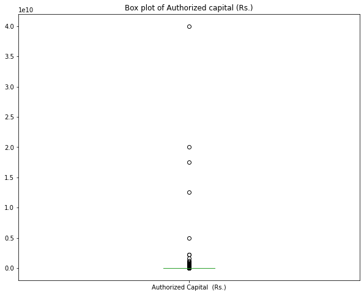

```python
plt.figure(figsize = (10, 8))
column.plot.box()
plt.title("Box plot of Authorized capital (Rs.)")
plt.show()
```

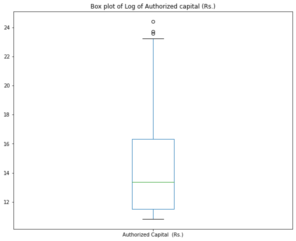

```python
logged = column.apply(lambda x: np.log(x))
plt.figure(figsize = (10, 8))
logged.plot.box()
plt.title("Box plot of Log of Authorized capital (Rs.)")
plt.show()
```

### PAIDUP_CAPITAL (Rs.)

Paid up capital in rupees (Rs.). Note: leading whitespace in column title.

```python
column = Dadra_Nagar_Haveli_2016[" PAIDUP_CAPITAL (RS.)"]
column
```

```
0        540000
1      48000000
2             0
3             0
4             0
         ...
467           0
468     8300000
469      100000
470      100000
471           0
Name:  PAIDUP_CAPITAL (RS.), Length: 472, dtype: int64
```

```python
# Number of 0 values
print("0 Capital:", sum(column == 0))
print("No. of unique values:", len(column.unique()))

# Summary Statistics
print("Min:", min(column))
print("Max:", max(column))
print("Mean:", statistics.mean(column))
print("Mode:", statistics.mode(column))
print("Median:", statistics.median(column))
```

```
0 Capital: 49
No. of unique values: 175
Min: 0
Max: 16980839640
Mean: 126049155.63347457
Mode: 100000
Median: 100000.0
```

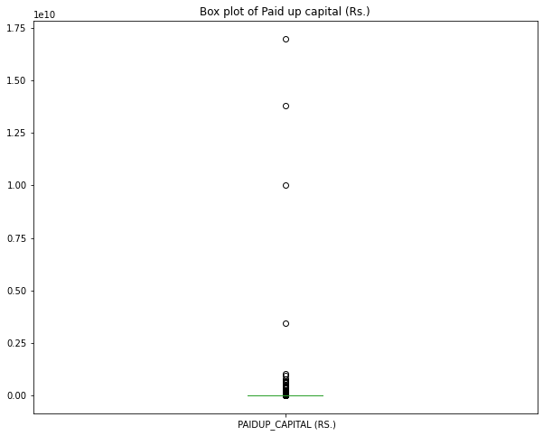

```python
plt.figure(figsize = (10, 8))
column.plot.box()
plt.title("Box plot of Paid up capital (Rs.)")
plt.show()
```

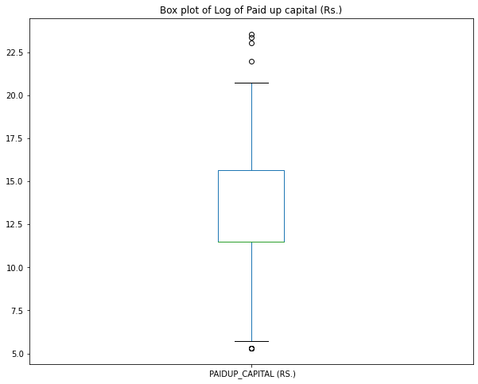

```python
logged = column.apply(lambda x: np.log(x))
plt.figure(figsize = (10, 8))
logged.plot.box()
plt.title("Box plot of Log of Paid up capital (Rs.)")
plt.show()
```

### PRINCIPAL_BUSINESS_ACTIVITY_CODE

Principal Business code that classifies the main type of product/service sold.

```python
column = Dadra_Nagar_Haveli_2016["PRINCIPAL_BUSINESS_ACTIVITY_CODE"]
column
```

```
0      51109
1      17291
2      99999
3      99999
4      99999
       ...
467    27209
468    27203
469    27203
470    17299
471    65191
Name: PRINCIPAL_BUSINESS_ACTIVITY_CODE, Length: 472, dtype: int64
```

```python
print("No. of unique values:", len(column.unique()))
print("Min:", min(column))
print("Max:", max(column))

# Table of number of each Principal Business Activity Code
counter = dict(Counter(column))
count = { key:[value] for key, value in counter.items()}
table = pd.DataFrame.from_dict(count).rename(columns={" ": "Empty"})
table = table.melt(var_name="Principal Business Activity Code", value_name="Count").sort_values(by=["Count"], ascending=False).reset_index(drop=True)
table
```

```
No. of unique values: 169
Min: 1111
Max: 99999
```

|  | Principal Business Activity Code | Count |
| --- | --- | --- |
| 0 | 45201 | 39 |
| 1 | 17119 | 39 |
| 2 | 99999 | 23 |
| 3 | 51900 | 17 |
| 4 | 74999 | 15 |
| ... | ... | ... |
| 164 | 24246 | 1 |
| 165 | 24247 | 1 |
| 166 | 24290 | 1 |
| 167 | 24294 | 1 |
| 168 | 65191 | 1 |

169 rows × 2 columns

### REGISTERED_OFFICE_ADDRESS

Address of registered office.

```python
column = Dadra_Nagar_Haveli_2016["REGISTERED_OFFICE_ADDRESS"]
column
```

```
0      PLOT NO 17, SURVEY NO 121/P,SILVASSA INDUSTRIA...
1      PLOT NO 65/B, PIPARIA INDUSTRIAL ESTATE,PIPARI...
2      SURVEY NO.210&ONS,VILLAGE MORKHAL,PO.SILVASSA ...
3      40-INDUS. ESTATE, PIPARIASILVASSADADAR N. HAVA...
4      C/O. SILPHAR LABORATORIES P.B.NO. 33SILVASSA (...
                             ...
467    216/4, NR. CANEL, DADRA NAGARHAVELI396 230 ( U...
468    PLOT NO. 110/2/4, HIMALAYA INDUSTRIAL ESTATENE...
469    S NO. 280/2/3/2, VELGAM, SILVASSA   SILVASSA I...
470    SURVEY NO 82/1/4, PLOT NO 70/6,DANUDYOG INDUST...
471                          123123   Hyderabad IN123123
Name: REGISTERED_OFFICE_ADDRESS, Length: 472, dtype: object
```

```python
# Number of invalid addresses
print("Invalid:", sum(column == "      IN"))
# -1 from invalid value
print("No. of unique values:", len(column.unique()) - 1)
```

```
Invalid: 0
No. of unique values: 421
```

```python
# Check for duplicates
counter = dict(Counter(column))
duplicates = { key:[value] for key, value in counter.items() if value > 1}
print("No. of Duplicates:", len(duplicates))

table = pd.DataFrame.from_dict(duplicates)
table = table.melt(var_name="Duplicate Registered Office Addresses", value_name="Count").sort_values(by=["Count"], ascending=False).reset_index(drop=True)
table
```

```
No. of Duplicates: 20
```

|  | Duplicate Registered Office Addresses | Count |
| --- | --- | --- |
| 0 | GALA NO.108, EVEREST INDUSTRIAL ESTATE,NEAR 66... | 11 |
| 1 | GALA NO.105, EVEREST INDUSTRIAL ESTATE,NEAR 66... | 9 |
| 2 | Gala No. 106, Everest Industrial Estate, Near ... | 6 |
| 3 | Gala No. 108, Everest Industrial Estate, Near ... | 4 |
| 4 | Gala No. 107, Everest Industrial Estate, Near ... | 4 |
| 5 | Gala No. 105, Everest Industrial Estate, Near ... | 4 |
| 6 | SURVEY NO. 119/6/2, VILLAGE : SILLISILVASSA, D... | 3 |
| 7 | GALA NO.107, EVEREST INDUSTRIAL ESTATE,NEAR 66... | 3 |
| 8 | GALA NO.106, EVEREST INDUSTRIAL ESTATE,NEAR 66... | 3 |
| 9 | 265, LAND MARK, KHANVEL ROAD,NR. DISTRICT COUR... | 3 |
| 10 | 258/1, UMARKUI ROAD,SAYALI SILVASSADadar & Na... | 2 |
| 11 | Shop No. 18, Plot No. 47, Haveli Falia, Jalara... | 2 |
| 12 | Gala No. 108, Everest Industrial Estate, Near ... | 2 |
| 13 | FLAT / E-10, YOGI VIHAR BUILDINGVILLAGE AMLI, ... | 2 |
| 14 | 260/23, SHEETAL INDUSTRIAL ESTATEDEMENI ROAD ... | 2 |
| 15 | Gala No. 107, Everest Industrial Estate,Near 6... | 2 |
| 16 | FLAT NO. G - 1,SILVER PARK, MASAT ROAD, SILVA... | 2 |
| 17 | 'HAVELI'SWAMINARAYAN MARG SILVASSADadar & Nag... | 2 |
| 18 | 112, GOKUL VIHAR,TOKARKHADA SILVASSADadar & N... | 2 |
| 19 | E/19, ZERO TAX INDUSTRIAL ESTATE, NEAR DADRA C... | 2 |

```python
Dadra_Nagar_Haveli_2016[Dadra_Nagar_Haveli_2016["REGISTERED_OFFICE_ADDRESS"].isin(duplicates)].sort_values('REGISTERED_OFFICE_ADDRESS')
```

|  | CIN | COMPANY_NAME | COMPANY_CLASS | COMPANY_CATEGORY | COMPANY_SUBCAT | COMPANY_STATUS | DATE_OF_REGISTRATION | REGISTERED_STATE | Authorized Capital (Rs.) | PAIDUP_CAPITAL (RS.) | PRINCIPAL_BUSINESS_ACTIVITY_CODE | REGISTERED_OFFICE_ADDRESS | EMAIL_ID | LATEST ANNUAL REPORT FILING FY END DATE | LATEST BALANCE SHEET FILING FY END DATE |
| --- | --- | --- | --- | --- | --- | --- | --- | --- | --- | --- | --- | --- | --- | --- | --- |
| 95 | U55101DN1995PTC000102 | HAVELI HERITAGE RESORTS PRIVATE LIMITED | Private | Company limited by Shares | Non-govt company | ACTIVE | 1995-12-28 | Dadra and Nagar Haveli | 6000000 | 102000 | 55101 | 'HAVELI'SWAMINARAYAN MARG SILVASSADadar & Nag... | haveli.group@gmail.com | 2015-03-31 | 2015-03-31 |
| 229 | U17119DN1995PTC000101 | HAVELI ENTERTAINMENTS PRIVATE LIMITED | Private | Company limited by Shares | Non-govt company | ACTIVE | 1995-12-28 | Dadra and Nagar Haveli | 41500000 | 40000000 | 17119 | 'HAVELI'SWAMINARAYAN MARG SILVASSADadar & Nag... | haveli.group@gmail.com | 2015-03-31 | 2015-03-31 |
| 336 | U01111DN2008PTC000278 | ADIS AGRO PRODUCTS PRIVATE LIMITED | Private | Company limited by Shares | Non-govt company | ACTIVE | 2008-04-23 | Dadra and Nagar Haveli | 1000000 | 0 | 1111 | 112, GOKUL VIHAR,TOKARKHADA SILVASSADadar & N... | lnmittal@dataone.in | 0 | 0 |
| 49 | U45201DN2008PLC000277 | AIF INFRASTRUCTURE LIMITED | Public | Company limited by Shares | Non-govt company | ACTIVE | 2008-04-23 | Dadra and Nagar Haveli | 500000 | 0 | 45201 | 112, GOKUL VIHAR,TOKARKHADA SILVASSADadar & N... | lnmittal@dataone.in | 0 | 0 |
| 133 | U17120DN2014PTC000465 | MUSKAN SPINTEX PRIVATE LIMITED | Private | Company limited by Shares | Non-govt company | ACTIVE | 2014-12-13 | Dadra and Nagar Haveli | 100000 | 100000 | 17120 | 258/1, UMARKUI ROAD,SAYALI SILVASSADadar & Na... | manoramaspintex@gmail.com | 0 | 0 |
| ... | ... | ... | ... | ... | ... | ... | ... | ... | ... | ... | ... | ... | ... | ... | ... |
| 137 | U17120DN2010PTC000332 | AASHISH POLYYARN PRIVATE LIMITED | Private | Company limited by Shares | Non-govt company | ACTIVE | 2010-06-29 | Dadra and Nagar Haveli | 100000 | 100000 | 17120 | SURVEY NO. 119/6/2, VILLAGE : SILLISILVASSA, D... | omfilam@yahoo.com | 2015-03-31 | 2015-03-31 |
| 25 | U17200DN2010PTC000330 | WATER TEX IMPEX PRIVATE LIMITED | Private | Company limited by Shares | Non-govt company | ACTIVE | 2010-06-16 | Dadra and Nagar Haveli | 100000 | 100000 | 17200 | SURVEY NO. 119/6/2, VILLAGE : SILLISILVASSA, D... | omfilam@yahoo.com | 2015-03-31 | 2015-03-31 |
| 136 | U17120DN2010PTC000333 | DEVESH POLYFAB PRIVATE LIMITED | Private | Company limited by Shares | Non-govt company | ACTIVE | 2010-06-29 | Dadra and Nagar Haveli | 100000 | 100000 | 17120 | SURVEY NO. 119/6/2, VILLAGE : SILLISILVASSA, D... | omfilam@yahoo.com | 2015-03-31 | 2015-03-31 |
| 380 | U51100DN2006PTC000409 | SAAR COMMODITIES PRIVATE LIMITED | Private | Company limited by Shares | Non-govt company | ACTIVE | 2006-02-10 | Dadra and Nagar Haveli | 3000000 | 2500000 | 51100 | Shop No. 18, Plot No. 47, Haveli Falia, Jalara... | saarcommodities@gmail.com | 2015-03-31 | 2015-03-31 |
| 176 | U67120DN2006PTC000408 | SAAR SECURITIES (INDIA) PRIVATE LIMITED | Private | Company limited by Shares | Non-govt company | ACTIVE | 2006-10-05 | Dadra and Nagar Haveli | 13000000 | 12100000 | 67120 | Shop No. 18, Plot No. 47, Haveli Falia, Jalara... | saarsec@gmail.com | 2015-03-31 | 2016-03-31 |

70 rows × 15 columns

Duplicates in `REGISTERED_OFFICE_ADDRESS` do not mean duplicates in companies. Sometimes a very small NGO cannot afford their own office, and will register their non-profit under another existing one. Also, some companies that share an address are branches of the same company.

### EMAIL_ID

Company email.

```python
column = Dadra_Nagar_Haveli_2016["EMAIL_ID"]
column
```

```
0                   rawal_bhv@yahoo.co.in
1                   rawal_bhv@yahoo.co.in
2
3
4
                      ...
467
468                  jainpack11@gmail.com
469       glacieraluminium@rediffmail.com
470    zayaan.kakajiwala@nzassociates.com
471                         xyz@gmail.com
Name: EMAIL_ID, Length: 472, dtype: object
```

```python
# Number of empty strings
print("Empty strings:", sum(column == " "))
# -1 from invalid value
print("No. of unique values:", len(column.unique()) - 1)

# Check for duplicates
counter = dict(Counter(column))
duplicates = { key:[value] for key, value in counter.items() if value > 1}
# Remove empty string duplicates
del duplicates[" "]
print("No. of Duplicates:", len(duplicates))

table = pd.DataFrame.from_dict(duplicates)
table = table.melt(var_name="Duplicate Email IDs", value_name="Count").sort_values(by=["Count"], ascending=False).reset_index(drop=True)
table
```

```
Empty strings: 80
No. of unique values: 350
No. of Duplicates: 27
```

|  | Duplicate Email IDs | Count |
| --- | --- | --- |
| 0 | spsspl@rediffmail.com | 8 |
| 1 | writegsd@gmail.com | 4 |
| 2 | lnmittal@dataone.in | 4 |
| 3 | kifs.roc@gmail.com | 3 |
| 4 | akparikh2007@gmail.com | 3 |
| 5 | omfilam@yahoo.com | 3 |
| 6 | gaganvmc@gmail.com | 3 |
| 7 | premkumar@alokind.com | 3 |
| 8 | cpf_dnh@yahoo.com | 2 |
| 9 | ganeshpatil2136@gmail.com | 2 |
| 10 | bstrpl@balbir.co.in | 2 |
| 11 | alpitgor@riddhicorporate.co.in | 2 |
| 12 | sec.shares@jbfmail.com | 2 |
| 13 | viren@ultrafabindia.com | 2 |
| 14 | pradip@navkardirect.com | 2 |
| 15 | dharmesh.bohra@gmail.com | 2 |
| 16 | rawal_bhv@yahoo.co.in | 2 |
| 17 | sudarshan_mi@sify.com | 2 |
| 18 | secretarial@todays-pens.com | 2 |
| 19 | info@sarlafibers.com | 2 |
| 20 | haveli.group@gmail.com | 2 |
| 21 | gkaiyerco@gmail.com | 2 |
| 22 | dnhprojects@gmail.com | 2 |
| 23 | rapportmumbai@hotmail.com | 2 |
| 24 | glacieraluminium@rediffmail.com | 2 |
| 25 | manoramaspintex@gmail.com | 2 |
| 26 | accounts@micromechpumps.com | 2 |

```python
Dadra_Nagar_Haveli_2016[Dadra_Nagar_Haveli_2016['EMAIL_ID'] == 'spsspl@rediffmail.com']
```

|  | CIN | COMPANY_NAME | COMPANY_CLASS | COMPANY_CATEGORY | COMPANY_SUBCAT | COMPANY_STATUS | DATE_OF_REGISTRATION | REGISTERED_STATE | Authorized Capital (Rs.) | PAIDUP_CAPITAL (RS.) | PRINCIPAL_BUSINESS_ACTIVITY_CODE | REGISTERED_OFFICE_ADDRESS | EMAIL_ID | LATEST ANNUAL REPORT FILING FY END DATE | LATEST BALANCE SHEET FILING FY END DATE |
| --- | --- | --- | --- | --- | --- | --- | --- | --- | --- | --- | --- | --- | --- | --- | --- |
| 117 | U45200DN2006PLC000193 | REALTIME PROPERTIES LIMITED | Public | Company limited by Shares | Non-govt company | ACTIVE | 2006-03-24 | Dadra and Nagar Haveli | 150000000 | 150000000 | 45200 | FLAT NO. G - 1,SILVER PARK, MASAT ROAD, SILVA... | spsspl@rediffmail.com | 2015-03-31 | 2015-03-31 |
| 128 | U74999DN1994PLC000073 | KRISHNA PROCON AND FINANCE LIMITED | Public | Company limited by Shares | Non-govt company | STRUCK-OFF | 1994-07-18 | Dadra and Nagar Haveli | 500000 | 700 | 74999 | 58B,DHANU UDYOG INDL.ESTATE,SILVASSA.(U.T.)DAD... | spsspl@rediffmail.com | 0 | 0 |
| 155 | U40100DN2005PLC000185 | KG CORPORATION LIMITED | Public | Company limited by Shares | Non-govt company | ACTIVE | 2005-09-02 | Dadra and Nagar Haveli | 650000000 | 649063000 | 40100 | 65, KRISHNA NAGAR,SAMARVANI, SILVASSAU.T. OF D... | spsspl@rediffmail.com | 2015-03-31 | 2015-03-31 |
| 187 | U67120DN1995PLC000094 | KRISHNA CREDITS AND CAPITAL LIMITED | Public | Company limited by Shares | Non-govt company | STRUCK-OFF | 1995-08-04 | Dadra and Nagar Haveli | 50000000 | 800 | 67120 | 58/A, DHANY UDYOG INDUSTRIAL AREAPIPERIA SILV... | spsspl@rediffmail.com | 0 | 0 |
| 235 | U17119DN1994PLC000072 | KRISHNA TEXPO AND FINANCIAL SERVICES LIMITED | Public | Company limited by Shares | Non-govt company | STRUCK-OFF | 1994-07-18 | Dadra and Nagar Haveli | 2000000 | 175852 | 17119 | 58B,DHANU UDYOG INDL.ESTATE,PIPERIA,SILVASSA. ... | spsspl@rediffmail.com | 0 | 0 |
| 344 | U65910DN2000PLC000147 | GLOBAL SOFTECH LIMITED | Public | Company limited by Shares | Non-govt company | ACTIVE | 2000-02-07 | Dadra and Nagar Haveli | 660000000 | 650000000 | 65910 | FLAT NO. G - 1,SILVER PARK, MASAT ROAD, SILVA... | spsspl@rediffmail.com | 2015-03-31 | 2015-03-31 |
| 388 | U72900DN2000PTC000156 | SINGLE POINT SECURITY SOLUTIONS PRIVATELIMITED | Private | Company limited by Shares | Non-govt company | ACTIVE | 2000-12-12 | Dadra and Nagar Haveli | 500000 | 500000 | 72900 | Gala No. 108, Everest Industrial Estate, Near ... | spsspl@rediffmail.com | 2015-03-31 | 2015-03-31 |
| 457 | U92110DN2003PTC000210 | 21ST CENTURY ENTERTAINMENT PRIVATELIMITED | Private | Company limited by Shares | Non-govt company | INACTIVE UNDER SECTION 455 OF CA,2013 | 2003-09-24 | Dadra and Nagar Haveli | 1000000 | 100000 | 92110 | H/B - 10, GURUDEV COMPLEX, PHASE II, SILVASS... | spsspl@rediffmail.com | 0 | 0 |

Duplicates in `EMAIL_ID` do not mean duplicates in companies.

### LATEST ANNUAL REPORT FILING FY END DATE

Latest annual report filing fiscal year end date.

```python
column = Dadra_Nagar_Haveli_2016["LATEST ANNUAL REPORT FILING FY END DATE"]
column
```

```
0      2015-03-31
1      2015-03-31
2               0
3               0
4               0
          ...
467             0
468    2015-03-31
469    2013-03-31
470             0
471             0
Name: LATEST ANNUAL REPORT FILING FY END DATE, Length: 472, dtype: object
```

```python
# Number of invalid values
print("Invalid:", (sum(column == "         0") + sum(column == 0)))
# -1 from invalid value
print("No. of unique values:", len(column.unique()) - 1)

# Count of Latest Annual report filing FY end date
counter = dict(Counter(column))
count = { key:[value] for key, value in counter.items()}
# Remove invalid date duplicates
del count["         0"]
del count[0]

print("Max:", max(count))
print("Min:", min(count))

table = pd.DataFrame.from_dict(count)
table = table.melt(var_name="Count of Latest Annual report filing FY end date", value_name="Count").sort_values(by=["Count"], ascending=False).reset_index(drop=True)
table
```

```
Invalid: 171
No. of unique values: 12
Max: 2016-03-31
Min: 2006-03-31
```

|  | Count of Latest Annual report filing FY end date | Count |
| --- | --- | --- |
| 0 | 2015-03-31 | 192 |
| 1 | 2014-03-31 | 45 |
| 2 | 2016-03-31 | 41 |
| 3 | 2013-03-31 | 9 |
| 4 | 2010-03-31 | 5 |
| 5 | 2011-03-31 | 3 |
| 6 | 2012-03-31 | 2 |
| 7 | 2009-03-31 | 1 |
| 8 | 2006-03-31 | 1 |
| 9 | 2014-12-31 | 1 |
| 10 | 2008-03-31 | 1 |

### LATEST BALANCE SHEET FILING FY END DATE

Latest balance sheet filing fiscal year end date.

```python
column = Dadra_Nagar_Haveli_2016["LATEST BALANCE SHEET FILING FY END DATE"]
column
```

```
0      2015-03-31
1      2015-03-31
2               0
3               0
4               0
          ...
467             0
468    2015-03-31
469             0
470             0
471             0
Name: LATEST BALANCE SHEET FILING FY END DATE, Length: 472, dtype: object
```

```python
# Number of invalid values
print("Invalid:", (sum(column == "         0") + sum(column == 0)))
# -1 from invalid value
print("No. of unique values:", len(column.unique()) - 1)

# Count of Latest Annual report filing FY end date
counter = dict(Counter(column))
count = { key:[value] for key, value in counter.items()}
# Remove invalid date duplicates
del count["         0"]
del count[0]

print("Max:", max(count))
print("Min:", min(count))

table = pd.DataFrame.from_dict(count)
table = table.melt(var_name="Count of Latest Annual report filing FY end date", value_name="Count").sort_values(by=["Count"], ascending=False).reset_index(drop=True)
table.head(10)
```

```
Invalid: 183
No. of unique values: 9
Max: 2016-03-31
Min: 2010-03-31
```

|  | Count of Latest Annual report filing FY end date | Count |
| --- | --- | --- |
| 0 | 2015-03-31 | 196 |
| 1 | 2016-03-31 | 52 |
| 2 | 2014-03-31 | 24 |
| 3 | 2013-03-31 | 8 |
| 4 | 2012-03-31 | 4 |
| 5 | 2011-03-31 | 3 |
| 6 | 2010-03-31 | 1 |
| 7 | 2014-12-31 | 1 |